# Estrategia de Crecimiento Cyclistic: Análisis del Comportamiento del Usuario

Author

Santiago Gonzalez

## Introducción

El objetivo de este proyecto es analizar los datos históricos de Cyclistic, una empresa de bicicletas compartidas, para identificar diferencias clave en el comportamiento de uso entre los miembros anuales y los usuarios ocasionales.

Este análisis busca generar recomendaciones basadas en datos para diseñar estrategias de marketing orientadas a convertir a los usuarios ocasionales en suscriptores a largo plazo, optimizando así la rentabilidad de la compañía.

## SOBRE LOS DATOS

Cyclistic, empresa ficticia de la ciudad de Chicago proporciona los datos mensuales sobre sus usuarios en una base de datos de internet. De allí se extrajeron los datos a trabajar durante el periodo de marzo 2025 y febrero 2026.

- **Metodología:** la limpieza se realizó mediante herramientas de procesamiento de datos para filtrar variables redundantes, normalizar formatos de fecha (Día/Mes/Año), eliminar valores nulos, inconsistentes o atipicos y asegurar la integridad de la información.
- **Métricas Creadas:** se calcularon variables críticas para el análisis, incluyendo la duración del viaje en minutos (ride_length), el día de la semana (day_of_week) y el mes del año.
- **Interfaz de codigo utilizada:** una vez normalizados los datos de cada mes de manera invidual, se cargo cada una de estas tablas en R, donde se juntaron los mismos para crear la tabla viajes_final, con mas de 4 millones de registros de viajes.

## PREPARACION DE LOS DATOS

Cargamos las librerías y el dataset de los 12 meses de viajes.

La tabla viajes_final es la que contiene los registros de los 12 meses estudiados. Esta tiene 8 variables.

1. Tipo de bicicleta
2. Estacion de inicio
3. Estacion final
4. Hora de comenzo del viaje
5. Hora de finalizacion del viaje
6. Tipo de usuario
7. Duracion del viaje
8. Dia de la semana del viaje

```r
#| echo: false

library(tidyverse)
# Cargamos la tabla
viajes_final <- readRDS("viajes_final.rds")
```

## ANALISIS EXPLORATORIO (EDA)

En esta etapa, el objetivo fue identificar las tendencias y comportamientos que diferencian a los **miembros anuales** de los **usuarios ocasionales**. Para ello, me enfoqué en cuatro pilares fundamentales: la duración de los viajes, la temporalidad, la ubicación geográfica y la preferencia de equipos.

**Diagnóstico de dispersión y sesgo en los datos crudos**

Antes de avanzar con las conclusiones de negocio, realicé un análisis de estadística descriptiva sobre el dataset original de más de 4 millones de registros. Fue en este punto donde detecté la primera señal de alerta en el comportamiento de los datos.

**El Hallazgo: una desviación estándar anómala**

Durante la fase inicial del **Análisis Exploratorio de Datos (EDA)**, se identificó una anomalía crítica en la variable de duración de los viajes. Se observó que la **desviación estándar** es significativamente más alta que la **media** (aproximadamente el doble), lo cual es un indicador estadístico de una **dispersión extrema** y la presencia de **valores atípicos (outliers)** que distorsionan el promedio.

Al contrastar las **medidas de tendencia central**, se detectó que la **media** se encuentra fuertemente sesgada hacia la derecha debido a su alta **sensibilidad a los valores extremos**. En cambio, la **mediana** se mantiene como una **medida robusta**, representando mejor al usuario típico de Cyclistic al no verse afectada por estos viajes de duración inusual.

| Tipo de Usuario | Promedio (min) | Mediana (min) | Desv. Estándar | Total Viajes |
| --- | --- | --- | --- | --- |
| casual | 22.04 | 12.55 | 50.32 | 1423491 |
| member | 12.37 | 8.70 | 25.54 | 2610251 |

**Identificación del Problema**

Este fenómeno reveló que el dataset contenía ruidos operativos: viajes que duraban cientos de minutos (posibles bicicletas no devueltas, errores de anclaje o robos). Si hubiera ignorado esta desviación de **50.32**, las recomendaciones de marketing para Cyclistic habrían estado basadas en una realidad distorsionada por valores atípicos.

Este hallazgo inicial fue el que motivó la necesidad de realizar un **Análisis de outliers** mediante diagramas de caja (boxplots) y un posterior filtrado técnico para normalizar la muestra.

Diagnóstico de Distribución: Cuartiles vs. Valores Extremos

| Tipo de Usuario | Q1 (P25) | Mediana (P50) | P90 | P95 | Máximo |
| --- | --- | --- | --- | --- | --- |
| casual | 7.07 | 12.55 | 43.95 | 65.10 | 1559.92 |
| member | 5.13 | 8.70 | 23.83 | 31.62 | 1499.97 |

```
El 50% central de los viajes dura entre 5.68 y 17.28 minutos.
```

```
El Rango Intercuartílico es de: 11.6
```

```
Cualquier viaje que supere los 34.68 minutos es estadísticamente un valor atípico.
```

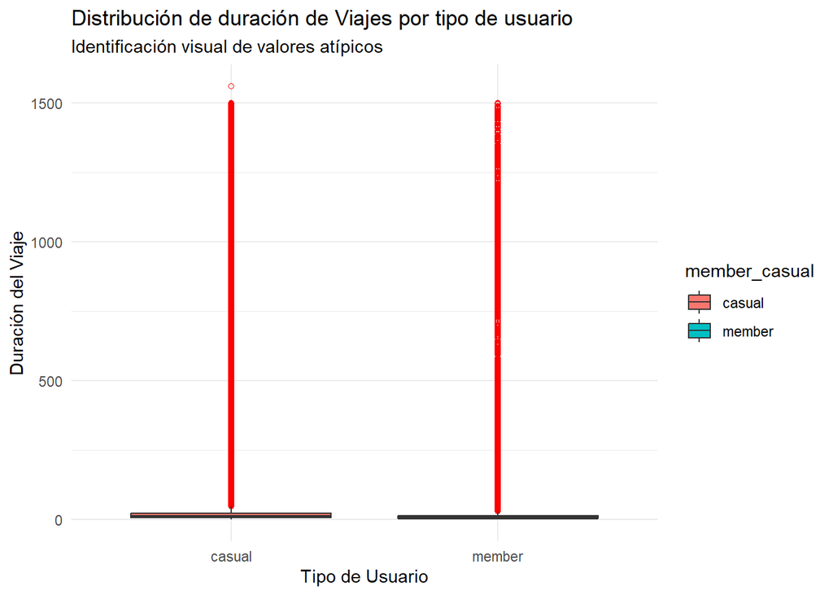

**Tratamiento de Outliers y Normalización de la Muestra**

Tras confirmar mediante la tabla de percentiles y el diagrama de cajas que los valores extremos (viajes de hasta 1,500 minutos) estaban distorsionando la realidad estadística, se procedió a la creación de una nueva tabla de análisis denominada `viajes_tipicos`.

**filter(ride_length > 1 & ride_length < 240)**

**Motivo de la elección del filtro:**

1. **Eliminación de falsos arranques:** Los viajes menores a un minuto suelen representar errores de anclaje, problemas técnicos con la bicicleta o usuarios que se arrepienten inmediatamente, por lo que no aportan valor al análisis de comportamiento.
2. **Exclusión de ruidos operativos:** Los viajes que exceden las 4 horas y llegan hasta las 24 o más se categorizaron como ruidos operativos (bicicletas perdidas, robos o fallas en el cierre del sistema). Incluirlos haría que la estrategia de marketing se base en errores y no en clientes reales.
3. **Enfoque en el uso recreativo y funcional:** Un límite de 4 horas es lo suficientemente amplio para captar incluso el uso recreativo más intenso, pero lo suficientemente estricto para eliminar los datos que sesgan la media.

Resumen Estadístico Comparativo: Usuarios Miembros vs. Casuales

| member_casual | Total Viajes | Media | Mediana | Desvío Estándar | RIC | MAD |
| --- | --- | --- | --- | --- | --- | --- |
| casual | 1404419 | 20.13 | 12.65 | 22.96 | 16.23 | 9.89 |
| member | 2583015 | 11.89 | 8.77 | 11.36 | 9.50 | 6.23 |

El análisis comparativo entre segmentos, tras normalizar la muestra (< 4hs), revela una diferencia estructural en el uso del servicio. Utilizando medidas robustas para evitar el sesgo de los valores extremos, se determinó que la **mediana** de duración para usuarios **casuales (12.65 min)** supera significativamente a la de los **miembros (8.77 min)**.

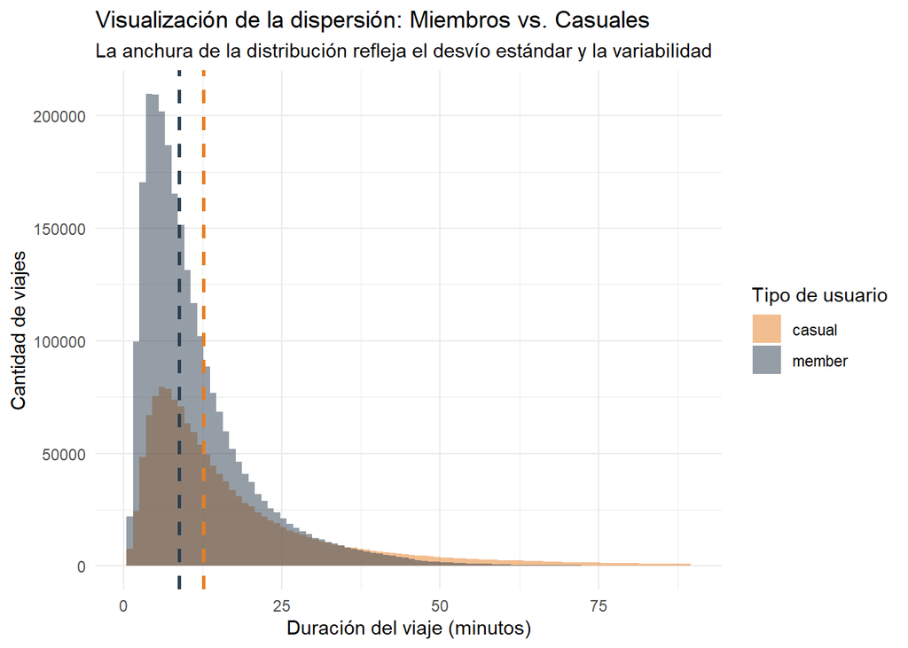

### Ahora que hemos analizado y normalizado los valores, continuamos con el analisis:

### 1. Análisis de la Duración de los Viajes

Para entender el uso que cada segmento le da a las bicicletas:

Tabla 1: Duración del Viaje Típico (Mediana)

| Tipo de Usuario | Duración Típica (min) |
| --- | --- |
| casual | 12.65 |
| member | 8.77 |

**En resumen:** la mediana nos permite concluir que existe una brecha clara en la finalidad del servicio: los miembros priorizan la rapidez del traslado, mientras que los usuarios casuales priorizan el tiempo de uso.

### 2. Comportamiento Temporal (Días y Meses)

Analicé el volumen de viajes distribuidos por día de la semana y mes del año para detectar picos de demanda.

**-Comportamiento semanal:**

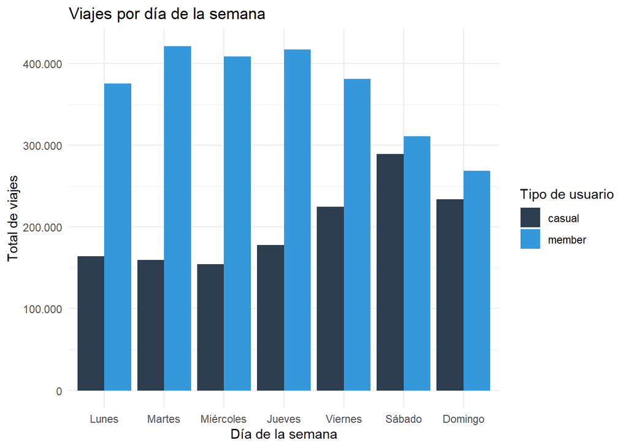

Distribución de viajes por día de la semana

**Días de la semana:** se observó un incremento masivo de usuarios ocasionales durante los fines de semana, mientras que los miembros mantienen un flujo constante y superior de lunes a viernes.

**-Comportamiento mensual:**

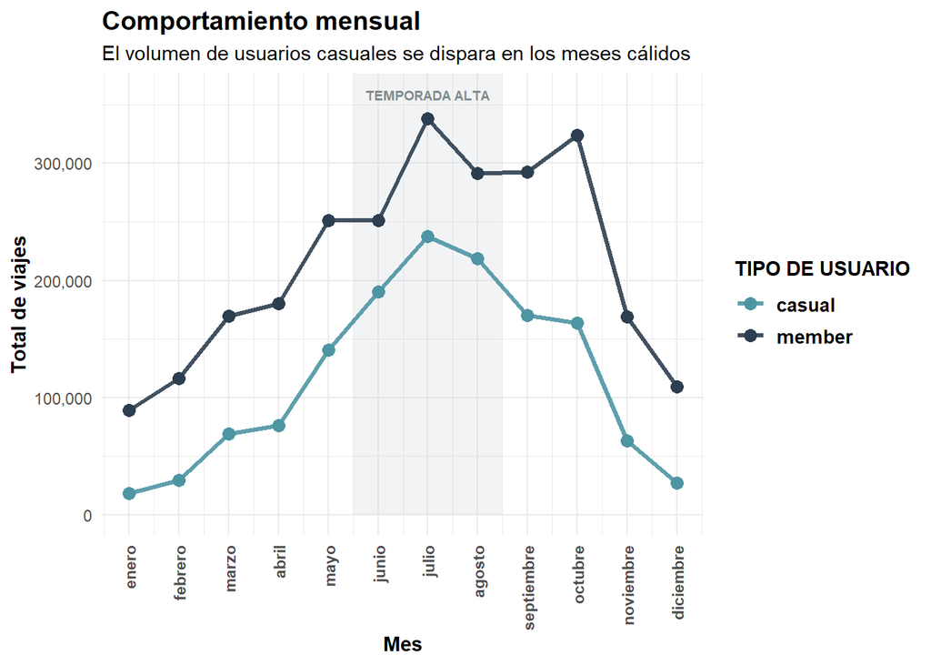

Distribución de viajes por mes

**Estacionalidad:** El volumen de viajes de usuarios ocasionales cae drásticamente en los meses de invierno, lo que refuerza la hipótesis del uso recreativo vinculado al clima.

### 3. Preferencia de estaciones y equipamiento

Identifiqué las 10 estaciones de inicio más populares para los usuarios ocasionales para localizar puntos estratégicos de conversión. Además, analicé la preferencia entre bicicletas clásicas y eléctricas.

**-Preferencias de estaciones:**

| ESTACION | Total Viajes |
| --- | --- |
| DuSable Lake Shore Dr & Monroe St | 28664 |
| Navy Pier | 25380 |
| Streeter Dr & Grand Ave | 21385 |
| Michigan Ave & Oak St | 20062 |
| DuSable Lake Shore Dr & North Blvd | 17356 |
| Millennium Park | 17092 |
| Shedd Aquarium | 15640 |
| Dusable Harbor | 13986 |
| Theater on the Lake | 13958 |
| Michigan Ave & 8th St | 10113 |

Distribución de viajes por zona

[figure not shown]

**Hallazgo:** las 10 estaciones mas demandadas por los usuarios casuales se encuentran en la zona costera de la ciudad. Puntos excelentes para la implementacion de carteleria fisica de publicidad.

-Preferencias de tipo de bicicleta:

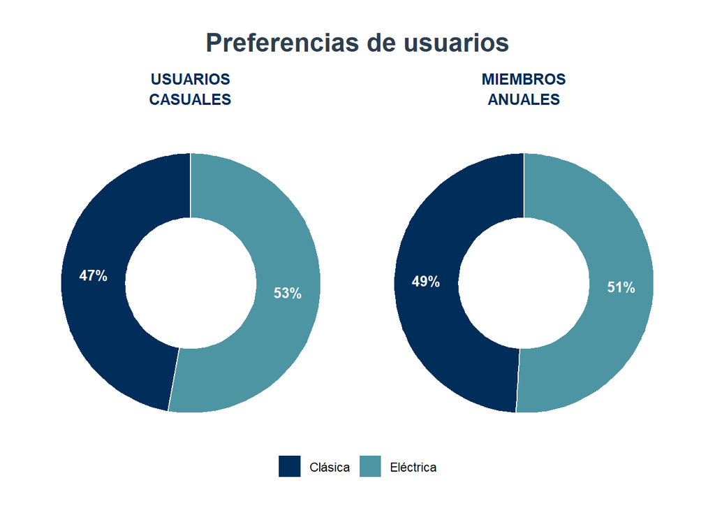

Distribución de viajes por tipo

Como podemos observar, no hay diferencia significativa en la elección de los usuarios ocasionales por un tipo específico de bicicleta.. Pero sí hay una leve preferencia por las bicicletas eléctricas, lo cual puede ser una buena idea lanzar promociones sobre este tipo de bicicletas en particular.

## Conclusiones y Recomendaciones Estratégicas

Basado en el análisis de los datos, se proponen las siguientes acciones:

1. **Campañas de conversión de fin de semana:** dado que el volumen de usuarios ocasionales alcanza su pico los sábados y domingos, se recomienda lanzar ofertas de membresía anual focalizadas en esos días.
2. **Marketing estacional:** aprovechar los meses de verano y primavera para captar a los usuarios recreativos, ofreciendo planes anuales con descuentos por suscripción anticipada.
3. **Publicidad localizada:** priorizar las campañas físicas en las 10 estaciones de mayor flujo detectadas en este análisis para maximizar el impacto visual en el público objetivo.